# Real-world Data Wrangling

## 1. Gather data

In this section, we will extract data using two different data gathering methods and combine the data. We will use a hardcopy CSV file as well as an appropriate API to retrieve data programmatically.

### **1.1.** Problem Statement

In this project, we will be determining if player engagement (e.g., playtime) for games available on the PC platform Steam is associated with lifetime, global sales. With this information, game developers and advertisers/marketers could determine games that are best for development, potential popularity for streaming and promotional partnerships, and factors related to creating games that could be considered generally "popular". I will analyze two datasets to answer this question: lifetime sales data for games and Steam engagement metrics.

### **1.2.** Gather at least two datasets using two different data gathering methods

#### **Dataset 1: Videogame Sales**

This dataset was chosen as it contains sales data on 16,500 different games over multiple decades and platforms. The dataset was downloaded in CSV format and loaded programmatically with Pandas. The variable below were selected to identify the PC game sales for comparison against engagement in the second dataset.

Type: CSV file

Method: This data was downloaded manually from [kaggle.com](https://www.kaggle.com/datasets/gregorut/videogamesales).

- *Local Directory*: Data/Raw/vgsales.csv

Dataset variables:

- *Variable 1*: Name: Name of the videogame
- *Variable 2*: Genre: Main genre of gameplay, used for analysis of popular games as well as a composite key to identify potential duplicates
- *Variable 3*: Publisher: Game publisher, will be used as a composite key to identify potential duplicates
- *Variable 4*: Global_Sales: Number of global sales, in millions which also indicates overall order of ranking for the game

```python
import pandas as pd
import numpy as np
import re
import itertools
import requests
from collections import defaultdict
import time
import matplotlib.pyplot as plt
import os, json
```

```python
# csv data loaded into dataframe
df_vgs = pd.read_csv("Data/Raw/vgsales.csv")
display(df_vgs.shape)
display(df_vgs.head())
```

```
(16598, 11)
```

|  | Rank | Name | Platform | Year | Genre | Publisher | NA_Sales | EU_Sales | JP_Sales | Other_Sales | Global_Sales |
| --- | --- | --- | --- | --- | --- | --- | --- | --- | --- | --- | --- |
| 0 | 1 | Wii Sports | Wii | 2006.0 | Sports | Nintendo | 41.49 | 29.02 | 3.77 | 8.46 | 82.74 |
| 1 | 2 | Super Mario Bros. | NES | 1985.0 | Platform | Nintendo | 29.08 | 3.58 | 6.81 | 0.77 | 40.24 |
| 2 | 3 | Mario Kart Wii | Wii | 2008.0 | Racing | Nintendo | 15.85 | 12.88 | 3.79 | 3.31 | 35.82 |
| 3 | 4 | Wii Sports Resort | Wii | 2009.0 | Sports | Nintendo | 15.75 | 11.01 | 3.28 | 2.96 | 33.00 |
| 4 | 5 | Pokemon Red/Pokemon Blue | GB | 1996.0 | Role-Playing | Nintendo | 11.27 | 8.89 | 10.22 | 1.00 | 31.37 |

#### Dataset 2: SteamSpy Player Engagement Metrics

This dataset was chosen to retrieve up-to-date information available on modern PC gamers from the SteamSpy API. It allows the perfect complement to the sales dataset as it has data from Steam, the most active, online gaming platform today (e.g. data on owners, playtime, regions, etc.).

Type: Electronic JSON data

Method: "API" method gathered from steamspy.com

- SteamSpy API: Returns JSON data, no API key required
- Endpoints:
  1. request=all to retrieve the overall directory and required appid information
  2. appdetails&appid= to retrieve stats for games to match the datasets

Dataset variables:

- *Variable 1*: appid: Steam ID to grab game details
- *Variable 2*: name: Name of the game on steam
- *Variable 3*: publisher: Game publisher, will be used as a join check against dataset 1
- *Variable 4*: owners: Number of owners of the game, in a range string
- *Variable 5*: average_forever: Overall playtime, in minutes, to determine overall engagement

Derived fields:

- *Variable 6*: name_key: A created key field for joining games together based on normalized titles
- *Variable 7/8/9*: owners_low; owners_midpoint; owners_high: Numeric midpoint determined from the owners range string
- *Variable 8*: hours_engagement = A created field consisting of average_forever / 60

Limitations:

- *Limitation 1*: Games identified are for PC/Steam only
- *Limitation 2*: SteamSpy provides values (e.g. 'owners') in range estimates and not exact number counts

```python
# Create function to normalize CSV PC game titles and allow fetching only the needed game id's from the SteamSpy API in below steps
def normalize_game_name(s: str):
    if s is None:
        return ""

    s = str(s).lower().strip()

    s = re.sub(r"[^a-z0-9]+", "", s)

    return s

# Test function

print(normalize_game_name("Medieval II: Total War Gold Edition"))
```

```
medievaliitotalwargoldedition
```

```python
# Map normalize_game_name function to PC games in CSV
pc_game = df_vgs['Platform'] == 'PC'

pc_title_name = df_vgs.loc[pc_game, 'Name']

pc_title_key = {n for n in (normalize_game_name(s) for s in pc_title_name.dropna()) if n}

title_sample = list(itertools.islice(pc_title_key, 5))

print(f"Number of unique PC game titles: {len(pc_title_key)}")
print(title_sample)
```

```
Number of unique PC game titles: 959
['commandconquer4tiberiantwilight', 'thegreatmysteryhiddenobjectpackage5', 'juiced2hotimportnights', 'anno2070', 'homeworld2']
```

```python
# Build appid list for what's available on Steam
app_list_url = "https://api.steampowered.com/ISteamApps/GetAppList/v2/"

app_list_response = requests.get(app_list_url)
app_list_data = app_list_response.json()

apps_listing = app_list_data.get("applist", {}).get("apps", [])

print(len(apps_listing))
print(apps_listing[0])
```

```
264874
{'appid': 5, 'name': 'Dedicated Server'}
```

```python
# Create the final, normalized list of appids to match against the CSV to fetch the final SteamSpy API list of matching game data
steam_titles = [
    (z['appid'], normalize_game_name(z['name'])) for z in apps_listing if z.get("name", "").strip()
]

appid_list = {appid for (appid, key) in steam_titles if key in pc_title_key}

print(len(appid_list))
```

```
621
```

```python
# Verify number of tiles with one vs multiple
steam_title_dict = defaultdict(list)
for appid, key in steam_titles:
    if key:
        steam_title_dict[key].append(appid)
```

```python
# Retrieve the data information from the SteamSpy api to create the inital dataframe
spy_url = "https://steamspy.com/api.php"

cache_responses = {}

for x in appid_list:
    params = {
        "request": "appdetails",
        "appid": x
    }

    spy_response = requests.get(spy_url, params)
    cache_responses[x] = spy_response.json()
    time.sleep(.2)

df_spy = pd.DataFrame.from_dict(cache_responses,orient='index')
df_spy.index.name = "appid"
```

```python
display(df_spy.shape)
display(df_spy.head())
```

```
(621, 20)
```

| appid | appid | name | developer | publisher | score_rank | positive | negative | userscore | owners | average_forever | average_2weeks | median_forever | median_2weeks | price | initialprice | discount | ccu | languages | genre | tags |
| --- | --- | --- | --- | --- | --- | --- | --- | --- | --- | --- | --- | --- | --- | --- | --- | --- | --- | --- | --- | --- |
| 32770 | 32770 | Joint Operations: Combined Arms Gold | NovaLogic | NovaLogic, THQ Nordic |  | 259 | 38 | 0 | 20,000 .. 50,000 | 2018 | 0 | 2018 | 0 | 1999 | 1999 | 0 | 5 | English | Action | {'Action': 29, 'Gore': 21, 'Multiplayer': 13, ... |
| 231430 | 231430 | Company of Heroes 2 | Relic Entertainment, Feral Interactive (Mac), ... | Relic Entertainment, Feral Interactive (Mac), ... |  | 86713 | 23112 | 0 | 5,000,000 .. 10,000,000 | 2419 | 310 | 289 | 275 | 499 | 1999 | 75 | 2330 | Czech, English, French, German, Italian, Polis... | Strategy | {'Strategy': 8476, 'World War II': 1768, 'RTS'... |
| 34830 | 34830 | Sniper: Ghost Warrior | City Interactive | CI Games |  | 4744 | 3381 | 0 | 1,000,000 .. 2,000,000 | 349 | 0 | 63 | 0 | 79 | 799 | 90 | 18 | English, French, German, Italian, Polish, Span... | Action | {'Action': 168, 'Sniper': 122, 'FPS': 81, 'Sin... |
| 1222670 | 1222670 | The Sims 4 | Maxis | Electronic Arts |  | 149064 | 21663 | 0 | 10,000,000 .. 20,000,000 | 1398 | 519 | 240 | 189 | 0 | 0 | 0 | 25276 | English, French, Italian, German, Spanish - Sp... | Adventure, Casual, Simulation, Free To Play | {'Life Sim': 2055, 'Character Customization': ... |
| 40980 | 40980 | Stronghold Legends: Steam Edition | FireFly Studios | FireFly Studios |  | 2120 | 312 | 0 | 200,000 .. 500,000 | 577 | 0 | 189 | 0 | 449 | 1499 | 70 | 57 | English, French, Italian, German, Spanish - Sp... | Simulation, Strategy | {'Real Time Tactics': 211, 'City Builder': 211... |

## 2. Assess data

### Quality Issue 1: Owners as string object, not numerical

```python
# Visual evidence
display(df_spy['owners'].dtype)
```

```
dtype('O')
```

```python
display(df_spy[['name','owners']].head())
```

| appid | name | owners |
| --- | --- | --- |
| 32770 | Joint Operations: Combined Arms Gold | 20,000 .. 50,000 |
| 231430 | Company of Heroes 2 | 5,000,000 .. 10,000,000 |
| 34830 | Sniper: Ghost Warrior | 1,000,000 .. 2,000,000 |
| 1222670 | The Sims 4 | 10,000,000 .. 20,000,000 |
| 40980 | Stronghold Legends: Steam Edition | 200,000 .. 500,000 |

```python
# Programmatic evidence
(df_spy['owners'].str.contains(f"\.\.", na=False)).sum()
```

```
621
```

Issue and justification:  
**Issue** - As previously indicated, the "owners" field in the SteamSpy data starts as a string object containing a range of numbers indicating number of owners of the game. The field should be contain numerical values such as the midpoint.

**Justification** - This is a quality issue as it prevents numerical analysis to make correlations on the number of owners and fields such as engagement time or sales. It also makes any appropriate plotting such as histogram binning or scatterplot points impossible.

We can see from the visual confirmations above that 'owners' is indeed an Object (string) and examples of 5 rows containing the unusable ranges. The programmatic evidence shows that *all* rows have a range entry.

### Quality Issue 2: Playtimes marked as "zero"

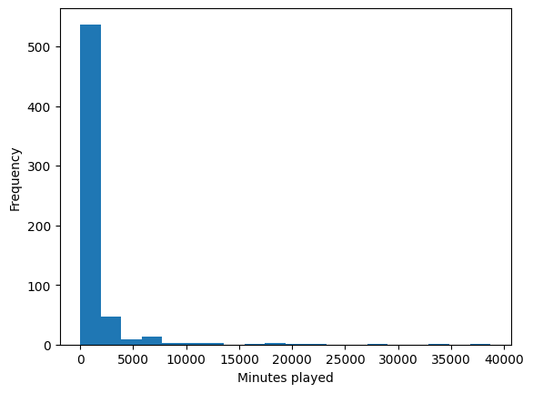

```python
# Visual evidence
df_spy['average_forever'].plot(kind="hist", bins=20)
plt.xlabel("Minutes played")
```

```python
df_spy.query('average_forever == 0').head()
```

| appid | appid | name | developer | publisher | score_rank | positive | negative | userscore | owners | average_forever | average_2weeks | median_forever | median_2weeks | price | initialprice | discount | ccu | languages | genre | tags |
| --- | --- | --- | --- | --- | --- | --- | --- | --- | --- | --- | --- | --- | --- | --- | --- | --- | --- | --- | --- | --- |
| 20509 | 20509 | Red Faction Guerrilla |  |  |  | 0 | 0 | 0 | 0 .. 20,000 | 0 | 0 | 0 | 0 | 0 | 0 | 0 | 0 |  |  | [] |
| 20520 | 20520 | S.T.A.L.K.E.R.: Clear Sky |  |  |  | 0 | 0 | 0 | 0 .. 20,000 | 0 | 0 | 0 | 0 | 0 | 0 | 0 | 0 |  |  | [] |
| 57419 | 57419 | Batman: Arkham City |  |  |  | 0 | 0 | 0 | 0 .. 20,000 | 0 | 0 | 0 | 0 | 0 | 0 | 0 | 0 |  |  | [] |
| 2717790 | 2717790 | Evolve Benchmark | Traverse Research | Traverse Research |  | 0 | 0 | 0 | 0 .. 20,000 | 0 | 0 | 0 | 0 | 1799 | 1799 | 0 | 0 | English | Utilities | [] |
| 16479 | 16479 | F.E.A.R. 2: Project Origin |  |  |  | 0 | 0 | 0 | 0 .. 20,000 | 0 | 0 | 0 | 0 | 0 | 0 | 0 | 0 |  |  | [] |

```python
# Programmatic evidence
zero_playtime = (df_spy['average_forever'] == 0).sum()
missing_playtime = df_spy['average_forever'].isna().sum()
total_games = len(df_spy)

print(f"Number of games with 0 playtime on average: {zero_playtime} vs Total Number of Games: {total_games}")

print(f"\nNumber of missing values for playtime on average: {missing_playtime}")
```

```
Number of games with 0 playtime on average: 135 vs Total Number of Games: 621

Number of missing values for playtime on average: 0
```

Issue and justification:  
**Issue** - One of the primary field for analysis, "average_forever", has multiple rows with 0 playtime listed per owner. Zeros may create issues in this context for analysis and correlations between playtime and sales as well as skew results in one direction.

**Justification** - The histogram above provides a visual highlight that numerous games peak on the lower end of the playtime spectrum with 0 appearing as an option, despite being popular games. The programmatic evidence identifies that 135 games have 0 playtime.

### Tidiness Issue 1: Individual titles may map to multiple appid's

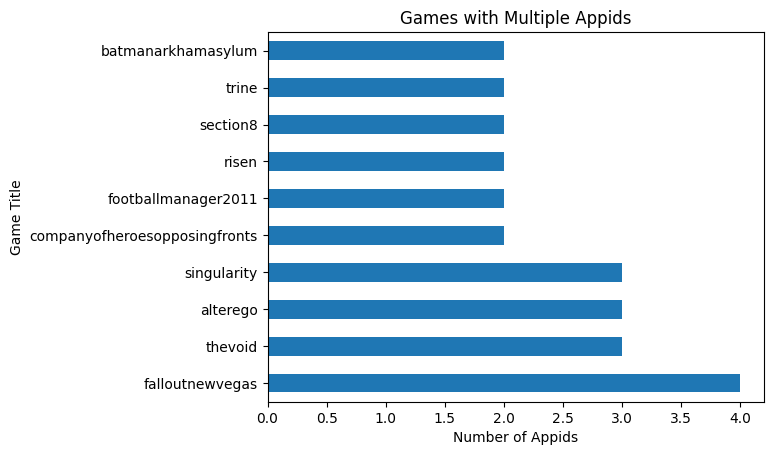

```python
# Visual evidence
appid_index = set(df_spy.index)

appid_counter = {k: len(appid_index & set(vals)) for k,vals in steam_title_dict.items()}

multi_count = {k: num for k,num in appid_counter.items() if num > 1}

df_count = pd.DataFrame(list(multi_count.items()), columns=['title_key', 'n_appids']).sort_values('n_appids', ascending=False).head(10)
df_count = df_count.set_index("title_key")

df_count['n_appids'].plot(kind="barh", title="Games with Multiple Appids", ylabel="Game Title", xlabel="Number of Appids")
```

```python
# Programmatic evidence
steam_keys = set(steam_title_dict.keys())
comparison_keys = pc_title_key & steam_keys

keys_less_than_one = [k for k in comparison_keys if len(steam_title_dict[k]) == 1]
keys_greater_than_one = [k for k in comparison_keys if len(steam_title_dict[k]) > 1]

more_than_one_total = sum(len(steam_title_dict[k]) for k in keys_greater_than_one)

print(f"Number of titles with 1 appid: {len(keys_less_than_one)}")
print(f"Number of titles with more than 1 appid: {len(keys_greater_than_one)}")
print(f"Total number of appids in titles with more than 1: {more_than_one_total}")
```

```
Number of titles with 1 appid: 450
Number of titles with more than 1 appid: 83
Total number of appids in titles with more than 1: 171
```

Issue and justification:  
**Issue** - Each game title only appears one time but, because of multiple Steam versions (e.g. "Complete", "Remaster", original game, etc.), when joining we will end up with a 'one-to-many' issue. Sales would appear as duplicates for multiple games that should only appear one time to avoid confusion on overall data accuracy.

**Justification** - As clearly identified by both the visual bar chart, which provides examples of 10 different titles with more than one appid as well as the programmatic evidence showing 83 titles with more than one id, the data must be cleaned to have a single appid.

### Tidiness Issue 2: Regional sales data is "wide" instead of "long"

```python
# Visual Evidence
region_columns = ['NA_Sales','EU_Sales','JP_Sales','Other_Sales']
df_vgs[region_columns + ['Global_Sales']].head()
```

|  | NA_Sales | EU_Sales | JP_Sales | Other_Sales | Global_Sales |
| --- | --- | --- | --- | --- | --- |
| 0 | 41.49 | 29.02 | 3.77 | 8.46 | 82.74 |
| 1 | 29.08 | 3.58 | 6.81 | 0.77 | 40.24 |
| 2 | 15.85 | 12.88 | 3.79 | 3.31 | 35.82 |
| 3 | 15.75 | 11.01 | 3.28 | 2.96 | 33.00 |
| 4 | 11.27 | 8.89 | 10.22 | 1.00 | 31.37 |

```python
# Programmatic evidence
total_regions = df_vgs[region_columns].sum(axis=1)

tolerance = .01
regional_global_diff = total_regions - df_vgs['Global_Sales']
print(regional_global_diff < tolerance)
```

```
0         True
1         True
2        False
3         True
4        False
         ...
16593     True
16594     True
16595     True
16596     True
16597     True
Length: 16598, dtype: bool
```

Issue and justification:  
**Issue** - The sales data for the "regions" was input in 4 different columns with a fifth column for "global sales" instead of a singular, long column for "Regions" and another column for "Total Sales". For proper data analysis and avoiding coding across four different columns (as seen in the two evidence cells above), the dataset should follow a 'one variable per column' rule. With the current setup, it could make analysis of specific regions and sales figures more difficult to parse out.

**Justification** - The visual evidence, a simple .head() for the dataset, clearly outlines the issue with multiple columns all representing sales with a total column at the end. With the programmatic evidence, we have found, with the exception of a few columns that were most likely created with rounding of values which resulted in being approximately a penny off, the regions all add up to the global_sales. This means the four, separate regions do not hold as much value in their current state as 'wide' fields.

**Fix** - The data would need to be adjusted to create four rows per game title in a single "Region" column and a total column for the Global Sales. For the purposes of this project, only Global Sales are needed overall since we will be measuring the volume of sales across the world against player engagement with the games played on a 'global gaming platform', Steam.

## 3. Clean data

```python
# CSV dataframe copy
df_vgs_working = df_vgs.copy()

df_vgs_working.head()
```

|  | Rank | Name | Platform | Year | Genre | Publisher | NA_Sales | EU_Sales | JP_Sales | Other_Sales | Global_Sales |
| --- | --- | --- | --- | --- | --- | --- | --- | --- | --- | --- | --- |
| 0 | 1 | Wii Sports | Wii | 2006.0 | Sports | Nintendo | 41.49 | 29.02 | 3.77 | 8.46 | 82.74 |
| 1 | 2 | Super Mario Bros. | NES | 1985.0 | Platform | Nintendo | 29.08 | 3.58 | 6.81 | 0.77 | 40.24 |
| 2 | 3 | Mario Kart Wii | Wii | 2008.0 | Racing | Nintendo | 15.85 | 12.88 | 3.79 | 3.31 | 35.82 |
| 3 | 4 | Wii Sports Resort | Wii | 2009.0 | Sports | Nintendo | 15.75 | 11.01 | 3.28 | 2.96 | 33.00 |
| 4 | 5 | Pokemon Red/Pokemon Blue | GB | 1996.0 | Role-Playing | Nintendo | 11.27 | 8.89 | 10.22 | 1.00 | 31.37 |

```python
# Create function to normalize publisher name on both datasets when cleaning below
def normalize_publisher_name(s: str):
    if s is None:
        return ""

    s = str(s).lower().strip()
    s = s.replace("&", " and ")

    s = re.sub(r"[^a-z0-9]+", "", s)

    return s
```

```python
# API dataframe copy and add a matching,normalized "name key" and publisher key to the SteamSpy working set for final cleaning
# and later joining
df_spy_working = df_spy.copy()

df_spy_working['name_key'] = df_spy_working['name'].map(normalize_game_name)
df_spy_working['publisher_key_spy'] = df_spy_working["publisher"].map(normalize_publisher_name)

df_spy_working.head()
```

| appid | appid | name | developer | publisher | score_rank | positive | negative | userscore | owners | average_forever | ... | median_2weeks | price | initialprice | discount | ccu | languages | genre | tags | name_key | publisher_key_spy |
| --- | --- | --- | --- | --- | --- | --- | --- | --- | --- | --- | --- | --- | --- | --- | --- | --- | --- | --- | --- | --- | --- |
| 32770 | 32770 | Joint Operations: Combined Arms Gold | NovaLogic | NovaLogic, THQ Nordic |  | 259 | 38 | 0 | 20,000 .. 50,000 | 2018 | ... | 0 | 1999 | 1999 | 0 | 5 | English | Action | {'Action': 29, 'Gore': 21, 'Multiplayer': 13, ... | jointoperationscombinedarmsgold | novalogicthqnordic |
| 231430 | 231430 | Company of Heroes 2 | Relic Entertainment, Feral Interactive (Mac), ... | Relic Entertainment, Feral Interactive (Mac), ... |  | 86713 | 23112 | 0 | 5,000,000 .. 10,000,000 | 2419 | ... | 275 | 499 | 1999 | 75 | 2330 | Czech, English, French, German, Italian, Polis... | Strategy | {'Strategy': 8476, 'World War II': 1768, 'RTS'... | companyofheroes2 | relicentertainmentferalinteractivemacferalinte... |
| 34830 | 34830 | Sniper: Ghost Warrior | City Interactive | CI Games |  | 4744 | 3381 | 0 | 1,000,000 .. 2,000,000 | 349 | ... | 0 | 79 | 799 | 90 | 18 | English, French, German, Italian, Polish, Span... | Action | {'Action': 168, 'Sniper': 122, 'FPS': 81, 'Sin... | sniperghostwarrior | cigames |
| 1222670 | 1222670 | The Sims 4 | Maxis | Electronic Arts |  | 149064 | 21663 | 0 | 10,000,000 .. 20,000,000 | 1398 | ... | 189 | 0 | 0 | 0 | 25276 | English, French, Italian, German, Spanish - Sp... | Adventure, Casual, Simulation, Free To Play | {'Life Sim': 2055, 'Character Customization': ... | thesims4 | electronicarts |
| 40980 | 40980 | Stronghold Legends: Steam Edition | FireFly Studios | FireFly Studios |  | 2120 | 312 | 0 | 200,000 .. 500,000 | 577 | ... | 0 | 449 | 1499 | 70 | 57 | English, French, Italian, German, Spanish - Sp... | Simulation, Strategy | {'Real Time Tactics': 211, 'City Builder': 211... | strongholdlegendssteamedition | fireflystudios |

5 rows × 22 columns

### **Quality Issue 1: Owners as string object, not numerical**

#### Cleaning Implementation

```python
# Function to update owners to low, mid, and high points
def owners_to_num(s: str):
    new_s = s.replace(",", "" )

    num1, num2 = [q.strip() for q in new_s.split("..")]

    num1, num2 = int(num1), int(num2)

    midpoint = (num1 + num2) / 2

    return num1, midpoint, num2

print(owners_to_num("50,000 .. 50,000"))
```

```
(50000, 50000.0, 50000)
```

```python
# Create the final, working dataframe for assessment, cleaning, and analysis
df_spy_final = df_spy_working[['name', 'publisher', 'owners', 'average_forever', 'name_key', 'publisher_key_spy']].copy()

df_spy_final[['owners_low', 'owners_midpoint','owners_high']] = df_spy_final['owners'].apply(owners_to_num).apply(pd.Series)
df_spy_final = df_spy_final.drop(columns=['owners'])
```

#### Cleaning Verification

```python
display(df_spy_final.shape)
display(df_spy_final.head())
```

```
(621, 8)
```

| appid | name | publisher | average_forever | name_key | publisher_key_spy | owners_low | owners_midpoint | owners_high |
| --- | --- | --- | --- | --- | --- | --- | --- | --- |
| 32770 | Joint Operations: Combined Arms Gold | NovaLogic, THQ Nordic | 2018 | jointoperationscombinedarmsgold | novalogicthqnordic | 20000.0 | 35000.0 | 50000.0 |
| 231430 | Company of Heroes 2 | Relic Entertainment, Feral Interactive (Mac), ... | 2419 | companyofheroes2 | relicentertainmentferalinteractivemacferalinte... | 5000000.0 | 7500000.0 | 10000000.0 |
| 34830 | Sniper: Ghost Warrior | CI Games | 349 | sniperghostwarrior | cigames | 1000000.0 | 1500000.0 | 2000000.0 |
| 1222670 | The Sims 4 | Electronic Arts | 1398 | thesims4 | electronicarts | 10000000.0 | 15000000.0 | 20000000.0 |
| 40980 | Stronghold Legends: Steam Edition | FireFly Studios | 577 | strongholdlegendssteamedition | fireflystudios | 200000.0 | 350000.0 | 500000.0 |

Justification:

The field was converted into three numerical columns using custom functions to split the strings and separate into low, mid, and high point owner numbers for each game. This is necessary to ensure all appropriate columns can be assessed and joined in later steps. The previous "owners" column was unnecessary and dropped.

### **Quality Issue 2: Playtimes marked as "zero"**

#### Cleaning Implementation

```python
# Add the boolean field to clearly highlight and control if a game has engagement or not and also
# added a quality field to turn minutes into hours for more human readable, and easier to analyze,
# information (e.g. "hours_engagement > 1" vs "79 minutes")
df_spy_final['hours_engagement'] = df_spy_final['average_forever'] / 60
df_spy_final['has_engagement'] = df_spy_final['hours_engagement'] != 0
```

#### Cleaning Verification

```python
display(df_spy_final.shape)
display(df_spy_final.head())
```

```
(621, 10)
```

| appid | name | publisher | average_forever | name_key | publisher_key_spy | owners_low | owners_midpoint | owners_high | hours_engagement | has_engagement |
| --- | --- | --- | --- | --- | --- | --- | --- | --- | --- | --- |
| 32770 | Joint Operations: Combined Arms Gold | NovaLogic, THQ Nordic | 2018 | jointoperationscombinedarmsgold | novalogicthqnordic | 20000.0 | 35000.0 | 50000.0 | 33.633333 | True |
| 231430 | Company of Heroes 2 | Relic Entertainment, Feral Interactive (Mac), ... | 2419 | companyofheroes2 | relicentertainmentferalinteractivemacferalinte... | 5000000.0 | 7500000.0 | 10000000.0 | 40.316667 | True |
| 34830 | Sniper: Ghost Warrior | CI Games | 349 | sniperghostwarrior | cigames | 1000000.0 | 1500000.0 | 2000000.0 | 5.816667 | True |
| 1222670 | The Sims 4 | Electronic Arts | 1398 | thesims4 | electronicarts | 10000000.0 | 15000000.0 | 20000000.0 | 23.300000 | True |
| 40980 | Stronghold Legends: Steam Edition | FireFly Studios | 577 | strongholdlegendssteamedition | fireflystudios | 200000.0 | 350000.0 | 500000.0 | 9.616667 | True |

```python
zero_playtime = (df_spy_final['average_forever'] == 0).sum()
missing_playtime = df_spy_final['average_forever'].isna().sum()
total_games = len(df_spy_final)

print(f"Number of games with 0 playtime on average: {zero_playtime} vs Total Number of Games: {total_games}")

print(f"\nNumber of missing values for playtime on average: {missing_playtime}")
```

```
Number of games with 0 playtime on average: 135 vs Total Number of Games: 621

Number of missing values for playtime on average: 0
```

Justification:

The zeroes, to avoid removing potentially legitimate data and because imputation does not appear to be a proper method for this project without introducing distortion or removing valid "zero playtime", were flagged to clearly highlight and control any items. This also keeps the data as clear, explicitly verified, and reproducible to verify results as possible.

### **Tidiness Issue 1: Individual titles may map to multiple appid's**

#### Cleaning Implementation

```python
# Normalize game title name and publisher in the sales dataset to match the SteamSpy dataset
df_vgs_working['name_key'] = df_vgs_working["Name"].map(normalize_game_name)
df_vgs_working["publisher_key_vgs"] = df_vgs_working["Publisher"].map(normalize_publisher_name)

df_vgs_pc_only = (df_vgs_working.loc[df_vgs_working['Platform'] == 'PC',
['Name', 'Platform', 'Year', 'Genre', 'NA_Sales', 'EU_Sales', 'JP_Sales', 'Other_Sales', 'Global_Sales', 'name_key','publisher_key_vgs']].dropna(subset=['name_key']))
```

```python
# Retrieve the keys (titles) we need for the final table list

allowed_keys = set(df_vgs_pc_only['name_key']) & set(df_spy_final['name_key'])

# Split the keys based on if they have one or more than one appid

totals = (df_spy_final.reset_index().groupby('name_key')['appid'].nunique())

singular_keys_allowed = [key for key in allowed_keys if totals.get(key,0) == 1]
multi_keys_allowed = [key for key in allowed_keys if totals.get(key,0) > 1]
```

```python
# Build final 'ranking' in case of duplicates or missing items to ensure only one key is used in the final join
# First is resetting the SteamSpy index that was originally set as the appID so we can use the previously established ranking of
# game title then publisher then the hours of engagement and finally the owners midpoint number if all else fails
multi_keys_for_use = (
    df_spy_final.reset_index()[['appid', 'name_key', 'publisher_key_spy', 'hours_engagement', 'owners_midpoint']]
    .merge(df_vgs_pc_only[['name_key', 'publisher_key_vgs']], on='name_key', how='inner')
    .query('name_key in @multi_keys_allowed')
)

multi_keys_for_use['matching_publisher'] = multi_keys_for_use['publisher_key_spy'] == multi_keys_for_use['publisher_key_vgs']

mutli_keys_selected = (multi_keys_for_use.sort_values(['name_key', 'matching_publisher', 'hours_engagement', 'owners_midpoint'],
                       ascending=[True, False, False, False])
                      .drop_duplicates(subset='name_key', keep='first')[['name_key','appid']])

# Add singular_keys to the table
singular_keys_for_use = (
    df_spy_final.reset_index().query('name_key in @singular_keys_allowed').groupby('name_key', as_index=False)['appid'].first()
)

# Combine the final sets of singular appid titles and the multiple appid titles that were reduced
# to one set of title:appid

final_keys = pd.concat([singular_keys_for_use, mutli_keys_selected], ignore_index=True)
final_keys_present = final_keys[final_keys['appid'].isin(df_spy_final.reset_index()['appid'])].copy()

# Complete the SteamSpy dataframe set with only one title to one appid to allow joining and final
# analysis
df_spy_final = (df_spy_final.merge(final_keys_present[['appid']], on='appid', how='inner').set_index('appid').sort_index())

df_spy_final['name_key'] = df_spy_final['name'].map(normalize_game_name)
```

#### Cleaning Verification

```python
# Verification to ensure final numbers in the keys dictionary matches the final dataframe table amounts
num_final_keys = len(final_keys_present)                # <-- 499 in your case
num_keys_in_df    = len(df_spy_final)
unique_names    = df_spy_final['name_key'].nunique()
duplicate_names     = df_spy_final['name_key'].duplicated().sum()

print(f"Number of titles in final set: {num_final_keys}")
print(f"Number of rows in dataframe: {num_keys_in_df}")
print(f"Unique game names:           {unique_names}")
print(f"Duplicate game names:        {duplicate_names}")
```

```
Number of titles in final set: 499
Number of rows in dataframe: 499
Unique game names:           499
Duplicate game names:        0
```

Justification:  
Before cleaning, multiple game titles could map to more than one Steam appid (remasters, game of the year editions, base game, etc.). This created 'one-to-many' join issues and duplicate potential. By building a normalized lookup table, game names were split into games with a single appid and those that had multiple appid's. To ensure matches were found and dealt with appropriately, the mutliple appid games were ranked by publisher, then highest engagement time, and then by the highest "owners_midpoint". The SteamSpy table was filtered to grab the keys present in both appropriate datasets and we verified there is one row per 'name_key'.

### **Tidiness Issue 2: Regional sales data is "wide" instead of "long"**

#### Cleaning Implementation

```python
# Melt the dataframe so the wide columns are converted to a long region column and appropriate regional sales
vgs_region_columns = ['NA_Sales', 'EU_Sales', 'JP_Sales', 'Other_Sales']

df_vgs_updated = (
    df_vgs_working.melt(id_vars=['Name', 'Platform', 'Year', 'Genre', 'Global_Sales'],
                   value_vars=vgs_region_columns,
                   var_name='Region', value_name='Regional_sales')
)
```

#### Cleaning Verification

```python
df_vgs_updated.head()
```

|  | Name | Platform | Year | Genre | Global_Sales | Region | Regional_sales |
| --- | --- | --- | --- | --- | --- | --- | --- |
| 0 | Wii Sports | Wii | 2006.0 | Sports | 82.74 | NA_Sales | 41.49 |
| 1 | Super Mario Bros. | NES | 1985.0 | Platform | 40.24 | NA_Sales | 29.08 |
| 2 | Mario Kart Wii | Wii | 2008.0 | Racing | 35.82 | NA_Sales | 15.85 |
| 3 | Wii Sports Resort | Wii | 2009.0 | Sports | 33.00 | NA_Sales | 15.75 |
| 4 | Pokemon Red/Pokemon Blue | GB | 1996.0 | Role-Playing | 31.37 | NA_Sales | 11.27 |

### **Remove unnecessary variables and combine datasets**

```python
# Create a cleaned and final video game sales table to join and not affect the tidiness data
df_clean_vgs = (
    df_vgs_working.loc[df_vgs_working['Platform'] == 'PC', ['Name', 'Platform', 'Year', 'Genre', 'Global_Sales']].copy()
)

df_clean_vgs['name_key'] = df_clean_vgs['Name'].map(normalize_game_name)

# Deduplicate any normalized titles that still exist

df_clean_vgs = (
    df_clean_vgs.sort_values(['name_key', 'Global_Sales', 'Year'], ascending=[True, False, True]).drop_duplicates('name_key', keep='first')
)

# Join the final, normalized tables
df_final_data = (
    df_spy_final.reset_index()
    .merge(df_clean_vgs[['name_key', 'Year', 'Genre', 'Global_Sales']], on='name_key', how='inner')
    .set_index('appid')
    .sort_index()
)

# Ensure final_data is 499 rows and there are no duplicate titles
assert len(df_final_data) == len(df_spy_final) == 499, "Final table MUST be 499 rows"
assert df_final_data['name_key'].duplicated().sum() == 0, "Duplicate titles are not allowed"

df_final_data.head()
```

| appid | name | publisher | average_forever | name_key | publisher_key_spy | owners_low | owners_midpoint | owners_high | hours_engagement | has_engagement | Year | Genre | Global_Sales |
| --- | --- | --- | --- | --- | --- | --- | --- | --- | --- | --- | --- | --- | --- |
| 70 | Half-Life | Valve | 530 | halflife | valve | 10000000.0 | 15000000.0 | 20000000.0 | 8.833333 | True | 1997.0 | Shooter | 4.12 |
| 220 | Half-Life 2 | Valve | 899 | halflife2 | valve | 10000000.0 | 15000000.0 | 20000000.0 | 14.983333 | True | 2004.0 | Shooter | 2.37 |
| 240 | Counter-Strike: Source | Valve | 7492 | counterstrikesource | valve | 10000000.0 | 15000000.0 | 20000000.0 | 124.866667 | True | 2004.0 | Shooter | 0.09 |
| 500 | Left 4 Dead | Valve | 949 | left4dead | valve | 5000000.0 | 7500000.0 | 10000000.0 | 15.816667 | True | 2008.0 | Shooter | 0.02 |
| 550 | Left 4 Dead 2 | Valve | 2384 | left4dead2 | valve | 50000000.0 | 75000000.0 | 100000000.0 | 39.733333 | True | 2009.0 | Shooter | 0.37 |

## 4. Update your data store

```python
# Saving csv file versions to the Data folders
df_spy.to_csv('Data/Raw/steamspy_raw.csv')
df_spy_final.to_csv('Data/Clean/steamspy_clean.csv')
df_vgs_updated.to_csv('Data/Clean/vgs_wide_to_long.csv')
df_clean_vgs.to_csv('Data/Clean/vgs_clean.csv')
df_final_data.to_csv('Data/Clean/final_clean.csv')
```

```python
# Keep documents available in a SQLite database as well as a document store for later updates
import sqlite3

db_connect = sqlite3.connect("Data/Database/spy_project.db")

df_spy_final.reset_index().to_sql("spy_clean", db_connect, if_exists="replace", index=False)
df_clean_vgs.to_sql("vgs_clean", db_connect, if_exists="replace", index=False)
df_final_data.reset_index().to_sql("final_data", db_connect, if_exists="replace", index=False)

db_connect.commit()
db_connect.close()
print("Tables have been saved/updated to Data/Database/spy_project.db")
```

```
Tables have been saved/updated to Data/Database/spy_project.db
```

```python
# SQL query check
db_connect = sqlite3.connect("Data/Database/spy_project.db")

query_test = """
SELECT appid, name, hours_engagement, Global_Sales, Year, Genre
FROM final_data
WHERE Global_Sales >= 2.0
ORDER BY Global_Sales DESC
LIMIT 5;
"""

testing = pd.read_sql_query(query_test, db_connect)

db_connect.close()
testing
```

|  | appid | name | hours_engagement | Global_Sales | Year | Genre |
| --- | --- | --- | --- | --- | --- | --- |
| 0 | 47890 | The Sims 3 | 51.300000 | 8.11 | 2009.0 | Simulation |
| 1 | 70 | Half-Life | 8.833333 | 4.12 | 1997.0 | Shooter |
| 2 | 72850 | The Elder Scrolls V: Skyrim | 118.100000 | 3.88 | 2011.0 | Role-Playing |
| 3 | 1222670 | The Sims 4 | 23.300000 | 2.97 | 2014.0 | Simulation |
| 4 | 1286830 | STAR WARS: The Old Republic | 45.683333 | 2.97 | 2011.0 | Role-Playing |

```python
# Document store for cache_responses

doc_store_path = "Data/Database/spy_documentation.json"
os.makedirs("Data/Database", exist_ok=True)

# Load documents from the file if they exist
docs = {}
if os.path.exists(doc_store_path) and os.path.getsize(doc_store_path) > 0:
    try:
        with open(doc_store_path) as spy:
            docs = json.load(spy)
    except json.JSONDecodeError:
        docs = {}

if 'cache_responses' in globals() and isinstance(cache_responses, dict):
    for appid, new_data in cache_responses.items():
        try:
            docs[str(int(appid))] = new_data
        except Exception:
            pass

with open(doc_store_path, "w") as spy:
    json.dump(docs, spy)

print(f"{len(docs)} raw documents stored in {doc_store_path}")
```

```
621 raw documents stored in Data/Database/spy_documentation.json
```

To provide additional storage options/access to the data, apart from the CSV's created earlier in step 4, I have ensure the clean/final tables are stored in a SQLite database. I have also used a SQL query to show the data is available and populates when a search is conducted. Finally, I create a simplistic document store for the SteamSpy raw JSON data, with the key of 'appid', for any future "updates" if they were to happen.

## 5. Answer the research question

### **5.1:** Define and answer the research question

**Question**: Is player engagement (e.g., playtime) for games available on the PC platform Steam associated with lifetime, global sales?

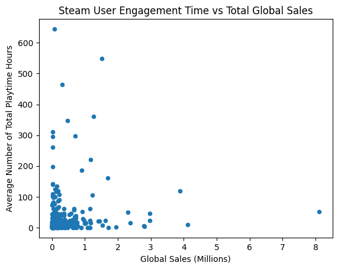

```python
df_final_data.plot(kind='scatter', x='Global_Sales', y='hours_engagement')
plt.title('Steam User Engagement Time vs Total Global Sales')
plt.xlabel('Global Sales (Millions)')
plt.ylabel('Average Number of Total Playtime Hours')
```

```python
corr1 = df_final_data[['Global_Sales', 'hours_engagement']].corr().iloc[0,1]
print(f"Pearson correlation: {corr1:.4f}")
```

```
Pearson correlation: 0.1381
```

*Answer to research question:*  
Using a linear Pearson method, this scatter plot shows us there is a weak association (r = approximately .14) between steam engagement playtime and the total, global sales of a game. Meaning, just because a game sells well, it does **not** mean players on Steam will put in more playtime because of the high sales. There are a few outliers, for instance, of games that had extremely high sales (e.g., > 8 million copies) but rather low average gametime compared to games with far fewer sales (eg. < 1 million copies) but averaged almost 500 hours of playtime. In a linear relationship, the data is right-skewed and the vast majority of games sell less than 1 million copies while giving gamers between 0 and 100 hours of average playtime.

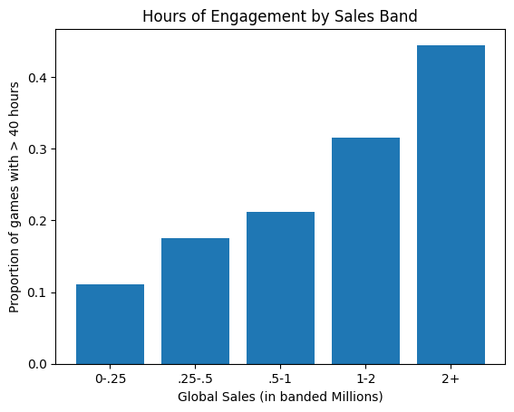

```python
sales_engagement = df_final_data.dropna(subset=['Global_Sales', 'hours_engagement'])
edges = [0, .25, .5, 1, 2, np.inf]
labels = ['0-.25', '.25-.5', '.5-1', '1-2', '2+']
bands = pd.cut(sales_engagement['Global_Sales'], bins=edges, labels=labels, right=False, include_lowest=True)

gaming_time = 40

sales_bands = sales_engagement.groupby(bands)['hours_engagement'].apply(lambda n: (n >= gaming_time).mean())

plt.bar(sales_bands.index.astype(str), sales_bands.values)
plt.xlabel("Global Sales (in banded Millions)")
plt.ylabel(f"Proportion of games with > {gaming_time} hours")
plt.title("Hours of Engagement by Sales Band")
```

*Answer to research question:*  
As a contrast, when using a proportional rank-based correlation of games with more than 40 hours of gameplay separated into sales bands, the proportion of time spent by players rises as sales bands increase. Meaning, games that sell better are more likely to be engaging and people put more time into the gameplay on average. The positive correlation is still only slight and this is a view of ranked sales, not a straight line correlation.

Overall, both visualizations and analysis provide the same outcome: there is a positive, but fairly weak, relationship between games with many sales receiving more game playtime from owners than games which don't reach as large of an audience. There are multiple areas of noise that could come into consideration and different factors such as genre and games being released in different eras (e.g. different capability for people to play games).

Limitations: The global sales are "retail" sales compared to more modern and digital PC game sales, sales for games only go up to the year 2020 for the available data, and the owner bins are coarse in nature.

### **5.2:** Reflection

In 2-4 sentences, if you had more time to complete the project, what actions would you take? For example, which data quality and structural issues would you look into further, and what research questions would you further explore?

*Answer:*  
With time to complete this project, I would look further into gathering a greater amount of data in the modern era (e.g. steam releases in the last 5 to 10 years). I would also create a more nuanced normalization method for titles to strip tokens of "GOTY" and "definitive" editions. I would also use more validation datasets for sales to provide more sourcing and reduce errors/noise where possible. I would love to explore different available factors such as which genres "get the most playtime" or finding what common features generated the most sales across the board.

### Final counts

```python
print(f"Video Game Sales original rows: {df_vgs.shape[0]}")
print(f"SteamSpy original rows: {df_spy.shape[0]}")

print(f"Final SteamSpy rows: {df_spy_final.shape[0]}")

print(f"Final joined/merged rows: {df_final_data.shape[0]}")
```

```
Video Game Sales original rows: 16598
SteamSpy original rows: 621
Final SteamSpy rows: 499
Final joined/merged rows: 499
```